# 06. 뉴스 키워드

### 자연어 처리

#### 절차

1. 수집
2. 전처리 (어휘분석, 불용어 처리, 형태소 분석)
3. 문서 표현 (VSM, Word Embedding, Documenet Embedding)
4. 차원 축소 (LSI, PCA, LDA)
5. 활용 (분류, 감성 분석, 정보 검색, 문서 요약, 챗봇, 기계 번역)
6. 평가 (혼동행렬, ROC, 정확도, 정밀도, 재현율, F1-Score)
- 불용어 : 불필요한 용어
- 형태소 분석 (Stemming) : 공통 어간을 가지는 단어를 묶는 작업을 Stemming
- 형태소 분석을 진행하기 위해 말뭉치 사전(Corpus) 필요, (SejongDic, NIADic)
- 정제된 텍스트 데이터는 n차원의 행렬로 구성 -> VSM(벡터 공간 모델), TVM(단어 벡터 모델) (Bag-of-words, N-gram, Ontology-based)
- 벡터 공간 모델의 차원을 축소 -> 분류(Document Classification), 감성 분석 (SNA)

```r
library(rJava)
```

- 오류 발생시 installr 패키지 다운 source(“https://install-github.me/talgalili/installr”) installr::install.java()

```r
library(remote)
```

```r
library(KoNLP)
```

remotes::install_github(“haven-jeon/KoNLP”, upgrade = “never”, INSTALL_opts = c(“–no-multiarch”))

#### httr 패키지를 이용하여 뉴스 데이터 수집하기

```r
library(httr)
```

네이버 오픈 API 종류 : https://developers.naver.com/docs/common/openapiguide/apilist.md

```r
URL = "https://openapi.naver.com/v1/search/news.json?"  # 네이버 뉴스 검색 API
search = "황의조"  # 키워드
cId <- "Mt8I_pQDaWDTGHwSd_pN"
cSec <- "0BGjzmfDrz"

news = GET(url = URL,  # URL
           add_headers("X-Naver-Client-Id" = cId,
                       "X-Naver-Client-Secret" = cSec),
           query = list(query = search,  # 키워드
                        display = 100,  # 100개
                        start = 1,  # 검색 결과 몇 번째 페이지 부터 조회할지 결정
                        sort = "date"))  # 날짜순 정렬
```

```r
httr::content(news)$total # 전체 뉴스 건수
```

```
## [1] 67603
```

httr::content(news) httr::content(news)$item

#### 뉴스 키워드 분석

```r
all_news = data.frame()
URL = "https://openapi.naver.com/v1/search/news.json?"
search = "황의조"

for(i in 1:10){
  param = list(query = search,
               display = 100,
               start = i,
               sort = "date")
  news = GET(url = URL,
             add_headers("X-Naver-Client-Id" = cId,
                         "X-Naver-Client-Secret" = cSec),
             query = param)
  body = data.frame(t(sapply(httr::content(news)$item, data.frame)))
  all_news = rbind(all_news, body)
  Sys.sleep(0.1)
}
dim(all_news)
```

```
## [1] 1000    5
```

```r
all_news[1,1]
```

```
## [[1]]
## [1] "한국축구 국가대표 일정, 2022카타르월드컵 최종예선순위 발표"
```

#### 뉴스 데이터 분석하기

```r
all_news$title[1:10]  # 10개의 기사 제목
```

```
## [[1]]
## [1] "한국축구 국가대표 일정, 2022카타르월드컵 최종예선순위 발표"
##
## [[2]]
## [1] "손흥민·황희찬 ‘춘천듀오' 이란 뚫는다"
##
## [[3]]
## [1] "벤투호, 손흥민·황희찬·<b>황의조</b> 소집…“조 1위 하겠다”"
##
## [[4]]
## [1] "1위 등극·미래 준비 ‘두 토끼’ 다 잡자"
##
## [[5]]
## [1] "벤투 감독 “카타르 월드컵 최종예선 조 1위 도전”"
##
## [[6]]
## [1] "&quot;월드 클래스 손흥민을…&quot; 코로나로 우울한 정국, 특급 소식 날아왔다"
##
## [[7]]
## [1] "'<b>황의조</b>와 결별' 효민, 요정의 환생? 감출 수 없는 미모 [리포트:컷]"
##
## [[8]]
## [1] "“적당한 거리 지켜야”…효민, <b>황의조</b> 결별 후 의미심장 글"
##
## [[9]]
## [1] "효민, '<b>황의조</b> 결별' 후 근황...시스루 입고 볼륨 몸매 자랑"
##
## [[10]]
## [1] "[리그1 현장 인터뷰] <b>황의조</b>, 보르도 잔류 다짐… “끝까지 포기 안 해”"
```

```r
pat = "<b>|</b>|&quot;" ; rep = ""
title = gsub(pattern = pat,
             replacement = rep,
             x = all_news$title)
head(title, 10)
```

```
##  [1] "한국축구 국가대표 일정, 2022카타르월드컵 최종예선순위 발표"
##  [2] "손흥민·황희찬 ‘춘천듀오' 이란 뚫는다"
##  [3] "벤투호, 손흥민·황희찬·황의조 소집…“조 1위 하겠다”"
##  [4] "1위 등극·미래 준비 ‘두 토끼’ 다 잡자"
##  [5] "벤투 감독 “카타르 월드컵 최종예선 조 1위 도전”"
##  [6] "월드 클래스 손흥민을… 코로나로 우울한 정국, 특급 소식 날아왔다"
##  [7] "'황의조와 결별' 효민, 요정의 환생? 감출 수 없는 미모 [리포트:컷]"
##  [8] "“적당한 거리 지켜야”…효민, 황의조 결별 후 의미심장 글"
##  [9] "효민, '황의조 결별' 후 근황...시스루 입고 볼륨 몸매 자랑"
## [10] "[리그1 현장 인터뷰] 황의조, 보르도 잔류 다짐… “끝까지 포기 안 해”"
```

사전 설정

```r
useNIADic()  # useSejongDic()
```

```
## Backup was just finished!
## 1213109 words dictionary was built.
```

명사 추출

```r
noun_list = extractNoun(title); head(noun_list)
```

```
## [[1]]
## [1] "한국축구"         "국가대표"         "일정"             "2022카타르월드컵"
## [5] "최종"             "예선"             "순위"             "발"
## [9] "표"
##
## [[2]]
## [1] "손흥민·황희찬" "‘춘천듀오'"    "이란"
##
## [[3]]
## [1] "벤투호"                 "손흥민·황희찬·황의조" "소집"
## [4] "“조"                   "1"                      "위"
## [7] "”"
##
## [[4]]
## [1] "1"          "위"         "등극·미래" "준비"       "‘두"
## [6] "토끼’"     "잡"
##
## [[5]]
##  [1] "투"       "감독"     "“카타르" "월드컵"   "최종"     "예선"
##  [7] "조"       "1"        "위"       "도전"     "”"
##
## [[6]]
##  [1] "월드"   "클래스" "손흥민" "코로나" "우울"   "한"     "정국"   "특급"
##  [9] "소식"   "날아왔"
```

BoW추출을 위해 명사가 몇 번 등장했는지 확인 (빈도수 테이블)

```r
tb_noun = table(unlist(noun_list))
length(tb_noun)
```

```
## [1] 349
```

```r
head(tb_noun)
```

```
##
##           '레알         '벤투호        '벤투호' '부상·코로나19        '손·황'
##              10              10              20              10              10
##    '손세이셔널'
##              10
```

```r
df_noun = data.frame(tb_noun)
(top10_noun = head(df_noun, 10))
```

```
##                Var1 Freq
## 1             '레알   10
## 2           '벤투호   10
## 3          '벤투호'   20
## 4   '부상·코로나19   10
## 5          '손·황'   10
## 6      '손세이셔널'   10
## 7  '손흥민·황의조'   10
## 8  '손흥민·황희찬'   10
## 9    '자신감+탁월한   10
## 10           [TEN★   10
```

#### 시각화

- 두 글자 이상인 것들에 대해서 빈도의 시각화

```r
library(ggplot2)
df_noun$Var1 = as.character(df_noun$Var1)  # 문자형으로 변경
df_noun = df_noun[nchar(df_noun$Var1) > 1,]  # 2글자 이상인 것들만 저장
(top10_noun = head(df_noun, 10))
```

```
##                Var1 Freq
## 1             '레알   10
## 2           '벤투호   10
## 3          '벤투호'   20
## 4   '부상·코로나19   10
## 5          '손·황'   10
## 6      '손세이셔널'   10
## 7  '손흥민·황의조'   10
## 8  '손흥민·황희찬'   10
## 9    '자신감+탁월한   10
## 10           [TEN★   10
```

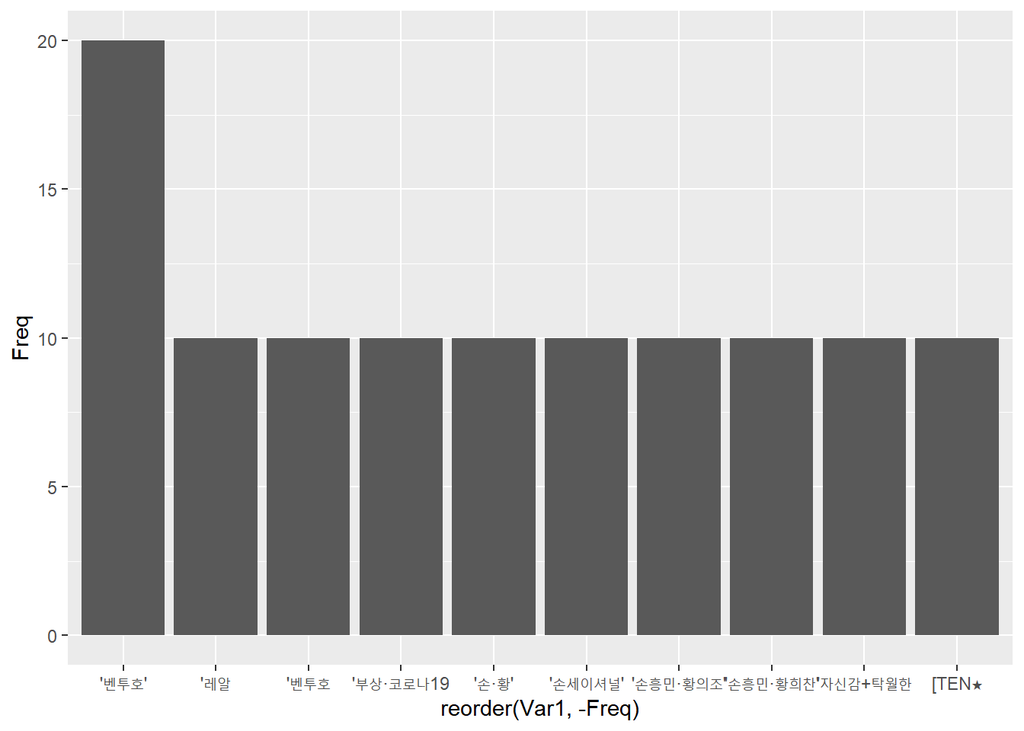

```r
ggplot(top10_noun) +
  geom_bar(aes(x = reorder(Var1, -Freq), y = Freq), stat = "identity")
```

#### 사전에 단어 추가

```r
term <- c("PSG", "벤투")
userDic <- data.frame(term = term, tag = "ncn")
```

term의 단어들을 명사(ncn)으로 추가

```r
buildDictionary(ext_dic = c("NIADic", "woorimalsam", "insighter", "sejong"),
                user_dic = userDic,
                replace_usr_dic = T)
```

```
## 1070022 words dictionary was built.
```

### 워드클라우드

```r
library(wordcloud2)
library(htmlwidgets)
library(jsonlite)
library(yaml)
library(base64enc)
library(wordcloud)
library(RColorBrewer)
library(wordcloud2)
```

library(devtools) install_github(“lchiffon/wordcloud2”)

#### 전처리

```r
pat = "<b>|</b>|&quot;|Q&amp;A" ; rep = ""
title = gsub(pattern = pat, replacement = rep, x = all_news$title)
title <- gsub('[[:punct:]]', replacement = rep, title)
title <- gsub('[[:cntrl:]]', replacement = rep, title)
title <- gsub('\\d+', rep, title)
head(title, 10)
```

```
##  [1] "한국축구 국가대표 일정 카타르월드컵 최종예선순위 발표"
##  [2] "손흥민황희찬 춘천듀오 이란 뚫는다"
##  [3] "벤투호 손흥민황희찬황의조 소집조 위 하겠다"
##  [4] "위 등극미래 준비 두 토끼 다 잡자"
##  [5] "벤투 감독 카타르 월드컵 최종예선 조 위 도전"
##  [6] "월드 클래스 손흥민을 코로나로 우울한 정국 특급 소식 날아왔다"
##  [7] "황의조와 결별 효민 요정의 환생 감출 수 없는 미모 리포트컷"
##  [8] "적당한 거리 지켜야효민 황의조 결별 후 의미심장 글"
##  [9] "효민 황의조 결별 후 근황시스루 입고 볼륨 몸매 자랑"
## [10] "리그 현장 인터뷰 황의조 보르도 잔류 다짐 끝까지 포기 안 해"
```

- 명사 추출

```r
noun_list = extractNoun(title)
```

- 단어 빈도 테이블

```r
tb_noun = table(unlist(noun_list))
```

- 문자형으로 변경

```r
df_noun = data.frame(tb_noun)
df_noun$Var1 = as.character(df_noun$Var1)  #
```

- 두 글자 이상인 것들만 저장

```r
df_noun = df_noun[nchar(df_noun$Var1) > 1,]
```

#### wordcloud 기본 시각화

- word : 단어
- freq : 단어들의 빈도
- size : 가장빈도가 큰 단어와 빈도가 가장 작은 단어 폰트 사이의 크기 차이
- min.freq : 출력될 단어의 최소 빈도
- max.word : 출력될 단어들의 최대개수
- random.order : TRUE 이면 램덤으로 단어출력, FALSE 이면 빈도수가 큰 단어일수록 중앙에 배치
- random.color : TRUE 이면 단어색은 랜덤순으로 정해지고, FALSE이면 빈도순으로 정해짐
- rot.per : 90도로 회전된 각도로 출력되는 단어의 비율
- colors : 가장 작은 빈도부터 큰 빈도까지의 단어색

[figure not shown]

```r
wordcloud(words = df_noun$Var1,
          freq = df_noun$Freq,
          random.order = F,
          min.freq = 10,
          colors = brewer.pal(8, "Dark2"))
```

#### wordcloud2

- data : 단어(word)와 빈도(freq) 컬럼을 갖는 데이터프레임
- size : 폰트 사이즈
- minSize : 서브타이틀 문자열
- gridSize : 그리드 사이즈
- fontFamily : 폰트 지정
- fontWeight : 폰트 볼드체 여부 지정 가능 (normal / bold / 600)
- color : 텍스트 색상 팔레트 (random-dark / random-light / 기타 컬러 벡터)
- backgroundColor : 배경 색 지정
- minRotation : 워드클라우드의 단어들을 회전시키려는 경우, 최소 회전각(rad 단위 입력) (* default : -pi/4)
- maxRotation : 워드클라우드의 단어들을 회전시키려는 경우, 최대 회전각(rad 단위 입력) (* default : pi/4)
- shuffle : (TRUE : 같은 데이터프레임이 주어져도 워드클라우드를 그릴 때마다 다른 결과값 표시)
- rotateRatio : 단어의 회전 확률 조절
- shape : 워드클라우드 형태(도형) 결정 (circle / cardioid / diamond / triangle-forward / triangle / pentagon / star)
- ellipticity : 워드클라우드 셰이프의 평평한 정도
- widgetsize : 위젯 사이즈
- figPath : 형태를 이미지 마스크로 지정할 경우, 해당 이미지의 경로와 파일명

```r
wordcloud2(data = df_noun,
           color = "random-dark",
           shape = "circle",
           fontFamily = "맑은고딕",
           fontWeight = 550,
           size = 2,
           widgetsize = c(900, 500))
```

[interactive chart not shown]

```r
wordcloud2(df_noun, figPath = "C:/Users/이찬솔/Desktop/숭실/R/실무 예제/Uijo.png")
```

[interactive chart not shown]

```r
letterCloud(df_noun, "HWANG", wordSize = 1)
```

[interactive chart not shown]

### 오늘의 뉴스 그래프로 분석하기

```r
URL = "https://openapi.naver.com/v1/search/news.json?"
search = "이강인"

all_news = data.frame()
for(i in 1:100){
   param = list(query = search,
                display = 100,
                start = i,
                sort = "sim")
   news = GET(url = URL,
              add_headers("X-Naver-Client-Id" = cId,
                          "X-Naver-Client-Secret" = cSec),
              query = param)
   body = data.frame(t(sapply(httr::content(news)$item, data.frame)))

   all_news = rbind(all_news, body)
   Sys.sleep(0.1)
}
```

```r
all_news[1,5]
```

```
## [[1]]
## [1] "Mon, 14 Mar 2022 17:02:00 +0900"
```

```r
format(Sys.time(), "%Y-%m-%d %a")
```

```
## [1] "2022-03-15 화"
```

```r
Sys.getlocale()
```

```
## [1] "LC_COLLATE=Korean_Korea.949;LC_CTYPE=Korean_Korea.949;LC_MONETARY=Korean_Korea.949;LC_NUMERIC=C;LC_TIME=Korean_Korea.949"
```

```r
Sys.setlocale(category = "LC_TIME", locale = "C")
```

```
## [1] "C"
```

```r
head(all_news$pubDate)
```

```
## [[1]]
## [1] "Mon, 14 Mar 2022 17:02:00 +0900"
##
## [[2]]
## [1] "Tue, 15 Mar 2022 00:31:00 +0900"
##
## [[3]]
## [1] "Mon, 14 Mar 2022 18:35:00 +0900"
##
## [[4]]
## [1] "Mon, 07 Mar 2022 07:42:00 +0900"
##
## [[5]]
## [1] "Mon, 07 Mar 2022 08:42:00 +0900"
##
## [[6]]
## [1] "Mon, 07 Mar 2022 21:02:00 +0900"
```

```r
all_news$pubDate = as.Date(unlist(all_news$pubDate), "%a, %d %b %Y")
head(all_news$pubDate)
```

```
## [1] "2022-03-14" "2022-03-15" "2022-03-14" "2022-03-07" "2022-03-07"
## [6] "2022-03-07"
```

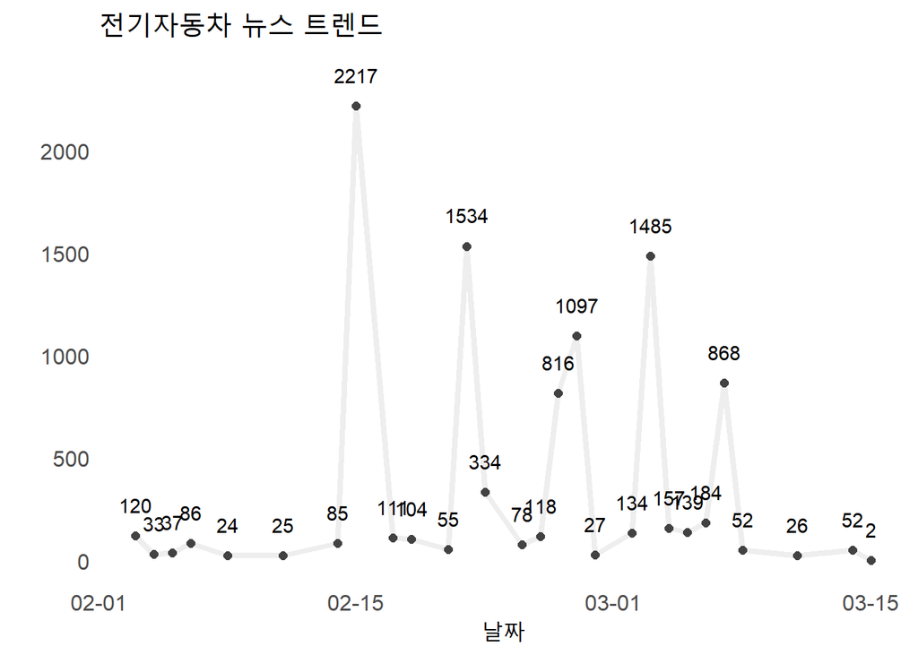

```r
ggplot(all_news, aes(x = pubDate)) +
   geom_line(stat = "count", color = "#EEEEEE", size = 1.5) +
   geom_point(stat = "count", color = "#424242", size = 2) +
   geom_text(aes(label = ..count..),
             stat = "count",
             position = position_nudge(y = 150)) +
   labs(title = "전기자동차 뉴스 트렌드") +
   xlab("날짜") +
   ylab("") +
   scale_x_date(date_labels = "%m-%d") +
   theme(text = element_text(size = 15),
         panel.background = element_blank(),
         axis.ticks = element_blank())
```

```r
pat = "<b>|</b>|&quot;|Q&amp;A" ; rep = ""
all_news$title = gsub(pattern = pat, replacement = rep, x = all_news$title)
all_news$title <- gsub('[[:punct:]]', replacement = rep, all_news$title)
all_news$title <- gsub('[[:cntrl:]]', replacement = rep, all_news$title)
all_news$title <- gsub('\\d+', rep, title)
```

```r
top <- data.frame(1:10)
for(i in 1:length(unique(all_news$pubDate))) {
   sub_news = all_news[all_news$pubDate == sort(unique(all_news$pubDate))[i],]
   df_target = data.frame(table(unlist(strsplit(sub_news$title, " "))))
   df_target = df_target[order(df_target$Freq, decreasing = TRUE),]
   df_target$Var1 = as.character(df_target$Var1)
   df_target = df_target[nchar(df_target$Var1) > 1 & nchar(df_target$Var1) < 7, ]

   top10 = head(df_target, 10)
   if (length(top10) < 10) {
      dif <- nrow(top) - nrow(top10)
      top10 <- data.frame(Var1 <- c(top10$Var1, rep(NA, dif)), Freq <- c(top10$Freq, rep(NA, dif)))
      colnames(top10) = c("Var1", "Freq")
   }
   top <- cbind(top, top10)
}
```

```r
top <- t(top)
top <- top[-1, ]
```

```r
key <- matrix(nrow = length(unique(all_news$pubDate)), ncol = 10)
for (i in 1:nrow(top)) {
   if (i%%2 == 1) {
      k <- i/2 + 1
      key[k,] <- top[i,]
   }
}
rownames(key) <- as.character(unique(all_news$pubDate))
colnames(key) <- paste(c(1:10), "위")
```

|  | 1 위 | 2 위 | 3 위 | 4 위 | 5 위 | 6 위 | 7 위 | 8 위 | 9 위 | 10 위 |
| --- | --- | --- | --- | --- | --- | --- | --- | --- | --- | --- |
| 2022-03-14 | 벤투호 | 이란전 | 최정예 | 발탁 | 목표 | 명단 | 손흥민 | 월드컵 | 조규성 | 황의조 |
| 2022-03-15 | 명단 | 발표 | 대표팀 | 손흥민 | 손흥민황희찬 | 최종예선 | 축구 | 합류 | 골잡이 | 대비 |
| 2022-03-07 | 최정예 | 벤투호 | 노린다 | 마친다 | 선발조위 | 소집해 | 예선 | 월드컵 | 이란전 | 확정 |
| 2022-03-03 | 이란전 | 벤투 | 벤투호 | 감독 | 최정예 | 발탁 | 명단 | 목표 | 이란 | 최종예선 |
| 2022-03-11 | 벤투호 | 월드컵 | 넣고 | 뛴다면 | 발탁 | 손흥민황의조 | 싶다 | 이란전 | 조규성 | 중요한 |
| 2022-03-06 | 깜짝 | 박민규이재익 | 발탁 | 배경은 | 벤투는 | 보수적인 | 없다 | 노린다 | 물오른 | 손흥민 |
| 2022-02-27 | 벤투호 | 박민규 | 수원FC | 발탁 | 최정예 | 대표팀 | K리거들에게 | 국가대표 | 깜짝 | 난적 |
| 2022-03-05 | 벤투호 | 이란전 | 최정예 | 발탁 | 벤투 | 명단 | 깜짝 | 박민규 | 최종예선 | 국가대표 |
| 2022-02-21 | 벤투 | 감독 | 벤투호 | 이란전 | 최정예 | 이란 | 깜짝 | 발탁 | 손흥민 | 황의조 |
| 2022-03-02 | 벤투 | 손흥민 | 명단 | 발표 | 유럽파 | A대표팀 | 국가대표 | 김동준 | 떠난 | 박민규 |
| 2022-02-26 | 앞세워 | 명단 | 공개 | 국가대표 | 김천상무 | 깜짝 | 도전 | 두렵지 | 만의 | 박민규이재익 |
| 2022-02-15 | 벤투호 | 발탁 | 벤투 | 이란전 | 명단 | 최정예 | 최종예선 | 감독 | 월드컵 | 깜짝 |
| 2022-03-04 | 벤투호 | 발탁 | 월드컵 | 이란전 | 최정예 | 조규성 | 최종예선 | 명단 | 손흥민황의조 | 김천상무 |
| 2022-02-22 | 국가대표 | 벤투호 | 손흥민 | 벤투 | 명단 | 발표 | 유럽파 | A대표팀 | vs | 경쟁 |
| 2022-02-17 | 발탁 | 벤투호 | 이란전 | 최정예 | 조규성 | 감독 | 박민규 | 벤투 | 손흥민황희찬 | 월드컵 |
| 2022-02-25 | 벤투호 | 이란전 | 최정예 | 발탁 | 벤투 | 조규성 | 황의조 | 이란 | 감독 | 깜짝 |
| 2022-02-20 | 벤투호 | 이란전 | 발탁 | 최정예 | 벤투 | 효민 | 조규성 | 깜짝 | 결별 | 박민규 |
| 2022-03-08 | 벤투호 | 국가대표 | 대표팀 | 명단 | 박민규 | 받았다 | 발탁 | 발표 | 부름 | 생애 |
| 2022-02-14 | 조규성 | 김천상무 | 국가대표 | 황의조 | 않고 | 잃지 | 초심 | vs | 거리가 | 걸린 |
| 2022-02-24 | 벤투호 | 최정예 | 이란전 | 발탁 | 효민 | 최종예선 | 벤투 | 결별 | 월드컵 | 명단 |
| 2022-02-18 | 벤투호 | 최정예 | 명단 | 이란 | 이란전 | 국가대표 | 박민규 | 조규성 | 황의조 | A대표 |
| 2022-02-28 | 벤투호 | 이란전 | 국가대표 | 김천상무 | 효민 | A매치 | TEN | 개월 | 거리가 | 걱정은 |
| 2022-02-11 | 벤투호 | 이란전 | 벤투 | 최정예 | 황의조 | 발탁 | 효민 | 결별 | 감독 | 대비 |
| 2022-02-08 | 벤투호 | 벤투 | 효민 | 발탁 | 이란전 | 결별 | 최종예선 | 황의조 | 최정예 | 감독 |
| 2022-02-06 | 벤투호 | 벤투 | 이란전 | 깜짝 | 발탁 | 강한 | 달성하겠다 | 명단 | 박민규 | 발탁종합 |
| 2022-02-05 | 벤투호 | 이란전 | 걱정은 | 공격 | 목표 | 변수 | 부상코로나 | 손황황 | 앞둔 | 없다 |
| 2022-02-04 | 벤투호 | 발탁 | 최정예 | 감독 | 난적 | 대비 | 마친다 | 맞대결 | 멤버 | 박민규 |
| 2022-02-03 | 국가대표 | 뚫는다 | 발표 | 손흥민황희찬 | 이란 | 일정 | 최종예선순위 | 춘천듀오 | 카타르월드컵 | 한국축구 |